# Reinforcement Learning

Here we program an agent that learns to navigate a map, using value iteration to find the best policy. That is, by repeatedly running the experiment, the agent gradually learns which actions give the highest reward from each state.

### Preliminaries

Some core concepts of Markov Decision Processes (MDPs):

- States. Each state associated with an inherent reward. Absorbing state = game over.
- Actions. Each state comes with a set of possible actions.
- Probability map. Given state + action, what's the probability of ending up in each of the other states? This can be initialised to give equal probability to each state, then updated through sampling. Or maybe it's known in advance and can be hardcoded.

Let's say we have a state `s_i`, reward `R_i` for that state, policy `pi` (that outputs an action `pi(s)` for that state). There's also a parameter `phi` called the discount factor. Then the expected reward when starting in that state is...

```
V(s_i) = R_i + phi \sum_{j} P_{s_i, pi(s_i)}(s_i) V(s_j).
```

Assuming we know `R_i` and `P_{s_i, a}` (for all actions `a`) perfectly, we can solve the resulting system of equations to determine `V(s_i)` for all `i`.

Our goal is to find an optimal policy `pi^*`. For this we use an algorithm called value iteration.

1. Initialise `V(s_i) = 0` for all `i`.
2. Set `V(s_i) := R_i + argmax_{a} phi \sum_{j} P_{s_i, a}(s_j) V(s_j)`.
3. Repeat until convergence.

This is guaranteed to find the optimal policy. If the state transition probabilities and/or rewards are unknown, then we can repeatedly run simulations to estimate them and update our policy each time.

### Imports

```python
import itertools
import numpy as np
import collections
import random
import matplotlib.pyplot as plt
from PIL import Image
```

### The Simulation

Define the "game": states, rewards, and possible actions. Goal is to get to the top right corner. There's also a bad position adjacent to the goal that we should avoid. This is based on an example in Andrew Ng's lectures, which in turn was taken from Norvig's AI book.

```python
W, H = 4, 3
STATES = list(itertools.product(range(H), range(W)))
END_STATES = set([
    (0, 3),
    (1, 3)
])
print("States:")
print(" ", STATES)

REWARDS = {}
REWARDS[(0, 3)] = 1
REWARDS[(1, 3)] = -1
for s in STATES:
    if s not in END_STATES:
        # Slightly negative reward for non-goal states to
        # discourage dilly-dallying.
        REWARDS[s] = -.1
print("Reward map:")
print(" ", REWARDS)

class Action:
    LEFT = "left"
    RIGHT = "right"
    UP = "up"
    DOWN = "down"
ACTIONS = (Action.LEFT, Action.RIGHT, Action.UP, Action.DOWN)
print("Actions:")
print(" ", ACTIONS)
```

```
States:
  [(0, 0), (0, 1), (0, 2), (0, 3), (1, 0), (1, 1), (1, 2), (1, 3), (2, 0), (2, 1), (2, 2), (2, 3)]
Reward map:
  {(0, 3): 1, (1, 3): -1, (0, 0): -0.1, (0, 1): -0.1, (0, 2): -0.1, (1, 0): -0.1, (1, 1): -0.1, (1, 2): -0.1, (2, 0): -0.1, (2, 1): -0.1, (2, 2): -0.1, (2, 3): -0.1}
Actions:
  ('left', 'right', 'up', 'down')
```

And the game logic.

```python
def transition(s, a):
    next_states, cumulative_distr = get_possible_next_states(s, a)
    return random.choices(next_states,
                          cum_weights=cumulative_distr)[0]

def get_possible_next_states(s, a, cumulative=True):
    if a == Action.LEFT:
        outcomes = [Action.UP, Action.DOWN, Action.LEFT]
    elif a == Action.RIGHT:
        outcomes = [Action.UP, Action.DOWN, Action.RIGHT]
    elif a == Action.UP:
        outcomes = [Action.LEFT, Action.RIGHT, Action.UP]
    else:
        outcomes = [Action.LEFT, Action.RIGHT, Action.DOWN]
    # BUG: multiple actions may lead to the same outcome, in which
    #      case we may need to de-duplicate this list.
    #      (It's fine for sampling, but bug-prone).
    return ([apply_action(s, outcome) for outcome in outcomes],
            (.125, .25, 1.) if cumulative else (.125, .125, .75))

def apply_action(s, a):
    i, j = s
    if a == Action.LEFT: j -= 1
    elif a == Action.RIGHT: j += 1
    elif a == Action.UP: i -= 1
    else: i += 1
    return (max(0, min(i, H-1)), max(0, min(j, W-1)))

def get_reward(s):
    return REWARDS[s] + np.random.normal(scale=.001)

def incorporate_stats(s_current, R_current, a, s_old, reward_estimate, state_count, transition_estimate):
    reward_estimate[s_current] += R_current
    state_count[s_current] += 1
    pair = (s_old, a)
    if pair not in transition_estimate:
        transition_estimate[pair] = collections.defaultdict(int)
    transition_estimate[pair][s_current] += 1

def simulate(policy_fn, s0=(2,2), max_steps=100, dropoff=.99):
    s_current = s0
    R = get_reward(s0)
    steps = 0
    reward_estimate = collections.defaultdict(float)
    reward_estimate[s_current] = R
    state_count = collections.defaultdict(int)
    state_count[s0] = 1
    transition_estimate = {}
    curr_dropoff = dropoff
    while s_current not in END_STATES and steps < max_steps:
        a = policy_fn(s_current)
        s_old = s_current
        s_current = transition(s_current, a)
        R_current = get_reward(s_current)
        R += curr_dropoff*R_current
        curr_dropoff *= dropoff

        # Update estimates.
        incorporate_stats(s_current, R_current, a, s_old, reward_estimate, state_count, transition_estimate)

        steps += 1
    end_states = set([s_current]) if s_current in END_STATES else set()
    # Return not only the final reward, but estimates of the rewards and
    # transition probabilities.
    return R, reward_estimate, state_count, transition_estimate, end_states
```

Test it out with a policy that picks a random action each time. (i.e. it's not a fixed policy).

```python
def random_policy(s):
    return random.choice(ACTIONS)
R, reward_estimate, state_count, transition_estimate, end_states = simulate(random_policy)
print("Reward:", R)
print("Reward estimate (by state):")
for s in STATES:
    print(" ", s, reward_estimate[s]/state_count[s]
                  if state_count[s] > 0
                  else "Never reached")
print("State counts:")
total_count = 0
for s, c in state_count.items():
    total_count += c
    print(" ", s, c)
print("Total count:", total_count)
print("Transition estimate:")
for pair in itertools.product(STATES, ACTIONS):
    if pair in transition_estimate:
        print(" ", pair, transition_estimate[pair])
print("End states:", end_states)
```

```
Reward: -0.15279179826506206
Reward estimate (by state):
  (0, 0) Never reached
  (0, 1) -0.09827322327816897
  (0, 2) -0.10052451242935982
  (0, 3) 1.0003209901458308
  (1, 0) Never reached
  (1, 1) -0.09950149171111555
  (1, 2) -0.10055114502555784
  (1, 3) Never reached
  (2, 0) Never reached
  (2, 1) -0.10063272594268527
  (2, 2) -0.10071028555084191
  (2, 3) Never reached
State counts:
  (2, 2) 2
  (1, 2) 3
  (1, 1) 2
  (2, 1) 1
  (0, 1) 1
  (0, 2) 2
  (0, 3) 1
  (0, 0) 0
  (1, 0) 0
  (1, 3) 0
  (2, 0) 0
  (2, 3) 0
Total count: 12
Transition estimate:
  ((0, 1), 'right') defaultdict(<class 'int'>, {(0, 2): 1})
  ((0, 2), 'left') defaultdict(<class 'int'>, {(1, 2): 1})
  ((0, 2), 'right') defaultdict(<class 'int'>, {(0, 3): 1})
  ((1, 1), 'left') defaultdict(<class 'int'>, {(2, 1): 1})
  ((1, 1), 'up') defaultdict(<class 'int'>, {(0, 1): 1})
  ((1, 2), 'up') defaultdict(<class 'int'>, {(0, 2): 1})
  ((1, 2), 'down') defaultdict(<class 'int'>, {(1, 1): 1, (2, 2): 1})
  ((2, 1), 'left') defaultdict(<class 'int'>, {(1, 1): 1})
  ((2, 2), 'left') defaultdict(<class 'int'>, {(1, 2): 1})
  ((2, 2), 'up') defaultdict(<class 'int'>, {(1, 2): 1})
End states: {(0, 3)}
```

Visualising the map.

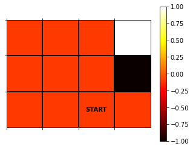

```python
board = np.array([
    [REWARDS[(i, j)] for j in range(W)]
    for i in range(H)])
plt.matshow(board, cmap='hot')
plt.colorbar()
plt.xticks(ticks=[x-0.5 for x in range(W)])
plt.yticks(ticks=[y-0.5 for y in range(H)])
plt.grid(c="black", lw=2)
f = plt.gca()
f.axes.xaxis.set_ticklabels([])
f.axes.yaxis.set_ticklabels([])
plt.text(1.7, 2.05, "START", weight="bold")
```

### Value iteration to find the optimal policy

First, supposing we've calculated the expected value from each state, we can construct the optimal policy. Let's also implement value iteration to actually calculate the expected values.

```python
def get_transition_prob(source, target, action, transition_probs):
    # Not exactly happy with how I've modelled the transition
    # probabilities, it's too ad-hoc. And assumes that there's an
    # entry for every state-action pair.
    return transition_probs[(source, action)].get(target, 0)

def make_optimal_policy(value_map, transition_probs):
    policy_map = make_optimal_policy_map(value_map, transition_probs)
    def policy(s):
        return policy_map[s]
    return policy

def make_optimal_policy_map(value_map, transition_probs):
    actions = {}
    for s in STATES:
        def action_expected_reward(a):
            return sum(get_transition_prob(s, new_s, a, transition_probs) * value_map[new_s]
                       for new_s in STATES)
        actions[s] = max(ACTIONS, key=action_expected_reward)
    return actions

def value_iteration(reward_map, transition_probs, dropoff,
                    initial_value_map=None, eps=.0001):
    value_map = (initial_value_map.copy()
                 if initial_value_map
                 else dict((s, 0) for s in STATES))
    while True:
        old_values = value_map.copy()
        diff = 0
        # SYNCHRONOUS update. We update all the expected values in lockstep, rather
        # than updating them one at a time and using the new values as they are
        # available (which would be asynchronous).
        for s in STATES:
            value_map[s] = (reward_map[s]
                            + max(dropoff*sum(get_transition_prob(s, t, a, transition_probs)*old_values[t]
                                              for t in STATES)
                                  for a in ACTIONS))
            diff += abs(value_map[s] - old_values[s])
        if diff < eps:
            break
    return value_map
```

Initialise our expected values and estimates of rewards/transition probs.

```python
value_map = {}
reward_map = {}
for s in STATES:
    value_map[s] = 0
    reward_map[s] = 0
transition_probs = {}
for pair in itertools.product(STATES, ACTIONS):
    # If there were more states we wouldn't be computing
    # all the transition probabilities like this...
    distr = {}
    transition_probs[pair] = distr
    for target in STATES:
        distr[target] = 1/len(STATES)
```

Now the main loop. In each iteration, run some simulations, then use the refined estimates of rewards / transition probabilities to update the expected values (via value iteration).

```python
dropoff = .99
reward_est, state_count, transition_est = None, None, None
policy = make_optimal_policy(value_map, transition_probs)
```

```python
rounds = 100
sims_per_round = 100
```

```python
for i in range(rounds):
    R_sum = 0
    for _ in range(sims_per_round):
        (R, sim_reward_est, sim_state_count,
            sim_transition_est, sim_end_states) = simulate(
            policy, dropoff=dropoff)
        R_sum += R
        # Incorporate the statistics from the simulation.
        if reward_est is None:
            reward_est = sim_reward_est
            state_count = sim_state_count
            transition_est = sim_transition_est
        else:
            for s, r in sim_reward_est.items(): reward_est[s] += r
            for s, c in sim_state_count.items(): state_count[s] += c
            for pair, sim_distr in sim_transition_est.items():
                if pair not in transition_est:
                    transition_est[pair] = sim_distr
                else:
                    distr = transition_est[pair]
                    for s, c in sim_distr.items():
                        distr[s] += c

    # Update estimates.
    for s in STATES:
        c = state_count[s]
        # Encourage to visit unknown states.
        reward_map[s] = 1 if c == 0 else reward_est[s]/c
    # Never goes anywhere, absorbing state.
    for pair in itertools.product(sim_end_states, ACTIONS):
        distr = transition_probs[pair]
        for t in distr:
            distr[t] = 0
    for pair, counts in transition_est.items():
        total_count = sum(counts.values())
        distr = transition_probs[pair]
        s, a = pair
        if total_count > 0:
            # Relying on the fact that we initialized this map so that
            # all the states have an entry.
            for t in distr:
                # For each target state, we update
                distr[t] = 0 if s not in counts else counts[t]/total_count

    # Update values.
    value_map = value_iteration(reward_map, transition_probs, dropoff, initial_value_map=value_map)

    # Update policy.
    policy = make_optimal_policy(value_map, transition_probs)

    # Print out the average score in each round, should indicate whether the
    # policy is improving as we gather more data.
    print(f"### Round {i}: {R_sum/sims_per_round}")
    print("  Reward map --", reward_map)
    print("  Value estimates --", value_map)
    print("  Policy --", make_optimal_policy_map(value_map, transition_probs))
    print()
```

[output not shown]

Visualising the policy we've derived.

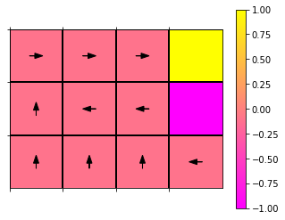

```python
board = np.array([
    [REWARDS[(i, j)] for j in range(W)]
    for i in range(H)])
plt.matshow(board, cmap='spring')
plt.colorbar()
plt.xticks(ticks=[x-0.5 for x in range(W)])
plt.yticks(ticks=[y-0.5 for y in range(H)])
plt.grid(c="black", lw=2)
f = plt.gca()
f.axes.xaxis.set_ticklabels([])
f.axes.yaxis.set_ticklabels([])
for s in STATES:
    if s in END_STATES:
        continue
    i, j = s
    dx, dy = 0, 0
    a = policy(s)
    if a == Action.DOWN: dy = .25
    elif a == Action.UP: dy = -.25
    elif a == Action.RIGHT: dx = .25
    else: dx = -.25
    plt.arrow(j-dx/2, i-dy/2, dx, dy, length_includes_head=True,
              head_width=0.1, fc="black")
```

### Evaluating the policy

As stated previously, for a given policy we can determine its exact expected value by solving a system of linear equations. The `i`-th state gives the following equation:

```
V(s_i) = R_i + phi \sum_{j} P_{s_i, pi(s_i)}(s_j) V(s_j),
\sum_{j} V(s_j) (phi P_{s_i, pi(s_i)}(s_j) - [i=j])  = -R_i,
```

where `phi` is the dropoff, and `[i=j]` is 1 if `i=j` and 0 otherwise. For this, let's use the true value transition probabilities & rewards rather than the estimates, though it might be interesting to see the difference between the estimated expected values and the true expected values.

```python
def eval_policy(policy, dropoff):
    state_to_index = {}
    i = 0
    for s in STATES:
        # The absorbing states have constant value, the system will end
        # up unsolvable if we include them.
        if s not in END_STATES:
            state_to_index[s] = i
            i += 1
    N = len(state_to_index)
    M = np.zeros((N,N))
    R = np.zeros(N)
    for s, i in state_to_index.items():
        R[i] = -REWARDS[s]
        for t, p in zip(*get_possible_next_states(s, policy(s), cumulative=False)):
            if t in END_STATES:
                # Expected value of an absorbing/end state is a constant term.
                R[i] -= dropoff*p*REWARDS[t]
            else:
                M[i, state_to_index[t]] = dropoff*p - (1 if s==t else 0)
    print(state_to_index)
    print(R)
    print(M)
    soln = np.linalg.solve(M, R)
    print(soln)
    print(np.dot(M, soln))
    V = dict([
        (s, REWARDS[s] if s in END_STATES else soln[state_to_index[s]])
        for s in STATES
    ])
    return V
```

Hmm, this is giving nonsensical values (e.g. expected value of >1 for many states). And I'm not that bothered to debug it.

```python
with np.printoptions(edgeitems=30, linewidth=100000,
        formatter=dict(float=lambda x: "%.5g" % x)):
    V = eval_policy(policy, dropoff)
print("Expected values by state!? --")
print(" ", V)
```

[output not shown]